# paipa_carol-90014679-week3_LogReg_XGB

## 6. Feature importance

### 6.1 Logistic Regression best model

- Test 1 SMOTE all features - had the best AUC on the test data

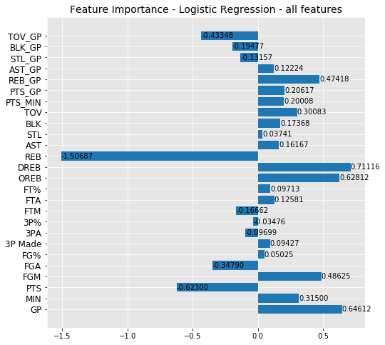

```python
IPython_default = plt.rcParams.copy()

# get importance
importance = lr_1.coef_[0]

# summarize feature importance
#for i,v in enumerate(importance):
# print('Feature: %0d, Score: %.5f' % (i,v))

# plot feature importance
plt.rcParams["figure.figsize"] = (8,8)
plt.rc('axes', facecolor='#E6E6E6', edgecolor='white',axisbelow=True, grid=True)
plt.rc('grid', color='w', linestyle='solid')

plt.barh([x for x in range(len(importance))], importance)
plt.yticks(np.arange(len(top_feat)),labels=top_feat, fontsize=12)
plt.yticks(fontsize=12)
plt.title('Feature Importance - Logistic Regression - all features', fontsize=14)

for i, v in enumerate(importance):
    # ax.text(v + 3, i + .25, str(v), color='blue', fontweight='bold')
    plt.text(v, i, '%.5f' % (v), va='center')

plt.show()
```

### 6.2 Logistic Regression best model - alternative approach

Converting the co-efficients into weights - calculate the Euler number to the power of its coefficient to find the importance.

https://sefiks.com/2021/01/06/feature-importance-in-logistic-regression/#:~:text=Feature%20importance%20is%20a%20common,regression%20and%20decision%20trees%20before

```python
# extract all coeffients
w0 = lr_1.intercept_[0]
w = w1, w2, w3, w4, w5, w6, w7, w8, w9, w10, w11, w12, w13, w14, w15, w16, w17, w18, w19, w20, w21 = lr_3.coef_[0]

print('Logistic regression model equation:')
equation = "y = %f + (%f * x1) + (%f * x2) + (%f * x3) + (%f * x4) + (%f * x5) + (%f * x6) + (%f * x7) + (%f * x8) ..." % (w0, w1, w2, w3, w4, w5, w6, w7, w8)
print(equation)
```

```
Logistic regression model equation:
y = 0.235940 + (0.656387 * x1) + (0.255579 * x2) + (-0.969588 * x3) + (0.848675 * x4) + (-0.250769 * x5) + (0.069118 * x6) + (0.226132 * x7) + (-0.222320 * x8) ...
```

```python
import math
def sigmoid(x):
    return 1 / (1 + pow(math.e, -x))

result = 0
result += w0
for i in range(0, len(top_feat)):
    result += X_train_res[i] * w[i]
result = sigmoid(result)
print(result)
```

```
[0.97627938 0.7520868  0.63560971 0.6480168  0.67265089 0.42689767
 0.21596383 0.32299968 0.26676933 0.71054831 0.44907902 0.9907575
 0.40355182 0.70236528 0.59169594 0.65540453 0.42208335 0.6944632
 0.85972534 0.27684942 0.20295164]
```

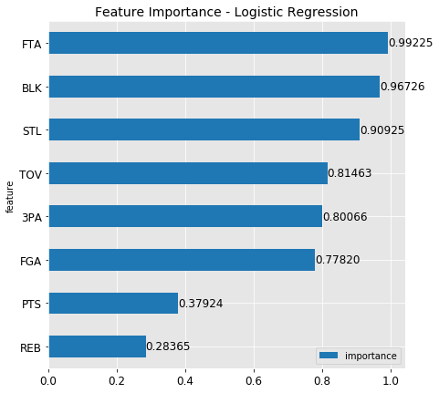

```python
# Feature importance - calculate the Euler number to the power of its coefficient to find the importance.

feature_importance = pd.DataFrame(top_feat, columns = ["feature"])
feature_importance["importance"] = pow(math.e, w)
feature_importance = feature_importance.sort_values(by = ["importance"], ascending=True)

# limit 10 highest features
feature_importance = feature_importance[0:8]

plt.rcParams["figure.figsize"] = (7,7)

from sklearn.linear_model import LogisticRegression
ax = feature_importance.plot.barh(x='feature', y='importance')
plt.xticks(fontsize=12)
plt.yticks(fontsize=12)
plt.title('Feature Importance - Logistic Regression', fontsize=14)

for i, v in enumerate(feature_importance["importance"]):
    # ax.text(v + 3, i + .25, str(v), color='blue', fontweight='bold')
    plt.text(v, i, '%.5f' % (v), va='center', fontsize=12)

plt.show()
```

### 6.3 Feature Importance - XGBoost

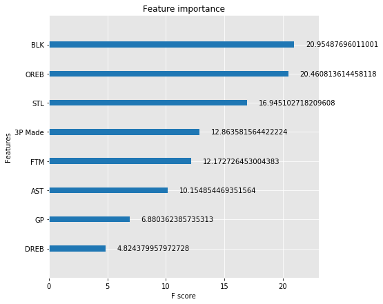

```python
# assign best model to generic variable
xgboost = xgboost3

feat_imp = xgboost.get_booster().get_score(importance_type="gain")

mapper = {'f{0}'.format(i): v for i, v in enumerate(df_clean_xgb.columns)}

mapping = {mapper[k]: v for k, v in feat_imp.items()}

plt.rcParams["figure.figsize"] = (7,7)

xgb.plot_importance(mapping, max_num_features=10)
```

### 6.4 Permutation Feature Importance

The **permutation feature importance** is the decrease in a model score when a single feature value is randomly shuffled. The score function to be used for the computation of importances can be specified with the scoring argument.

Apply to both 'best' models.

```python
from sklearn.inspection import permutation_importance

def define_permuatation_importance(model, X_train, Y_train):
    r = permutation_importance(
        model, X_train, Y_train,
        n_repeats=30,
        random_state=random_state
    )
    for i in r.importances_mean.argsort()[::-1]:
         print(f"{df_clean_mod.columns[i]}: {r.importances_mean[i]:.5f}")
```

```python
# Permuation importance - XGBoost best model
define_permuatation_importance(xgboost, X_train_res, y_train_res)
```

```
BLK: 0.06610
OREB: 0.02176
STL: 0.01849
3P Made: 0.01678
FTM: 0.00965
GP: 0.00446
AST: 0.00445
DREB: 0.00078
```

```python
# Permuation importance - Logisitic Regression best model
define_permuatation_importance(lr_1, X_train_save, y_train_save)
```

```
GP: 0.09596
DREB: 0.08150
OREB: 0.06940
FGM: 0.04649
REB: 0.04247
REB_GP: 0.03756
TOV_GP: 0.02803
MIN: 0.02084
PTS: 0.02049
TOV: 0.01948
PTS_MIN: 0.01159
FGA: 0.01021
PTS_GP: 0.00907
AST: 0.00592
AST_GP: 0.00324
FTM: 0.00288
BLK: 0.00256
FTA: 0.00096
FG%: 0.00090
3P Made: 0.00083
BLK_GP: 0.00080
FT%: 0.00073
3PA: 0.00033
STL_GP: 0.00025
3P%: 0.00008
STL: -0.00228
```

### 6.5 Partial Plot Dependence

Partial dependence plots **(PDP)** show the dependence between the target response and a set of input features of interest, marginalizing over the values of all other input features (the ‘complement’ features). Intuitively, we can interpret the partial dependence as the expected target response as a function of the input features of interest.

https://scikit-learn.org/stable/modules/partial_dependence.html

```python
from sklearn.inspection import plot_partial_dependence

def plot_pdp(model, X, feature_name, feature_cols, target_classes):
    feature_index = feature_cols.get_loc(feature_name)

    print(f"PDP for `{feature_cols[feature_index]}` ({feature_index}) with {target_classes}")

    plt.rcParams["figure.figsize"] = (4,4)

    for target_class in target_classes:
        plot_partial_dependence(model, X, features=[feature_index], target=target_class)

target_classes=[0, 1]
```

```
Partial Dependence Plot - Logistic Regression
PDP for `3P Made` (6) with [0, 1]
```

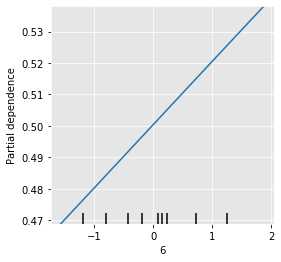

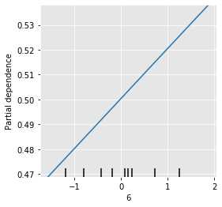

```python
print('Partial Dependence Plot - Logistic Regression')
plot_pdp(model=lr_1, X=X_train_save, feature_name='3P Made', feature_cols=df_clean_mod_lr.columns, target_classes=target_classes)
```

```
Partial Dependence Plot - XGBoost
PDP for `3P Made` (1) with [0, 1]
```

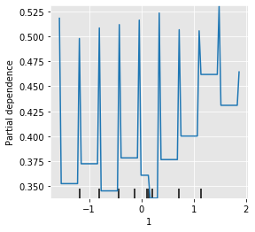

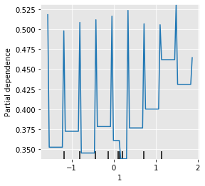

```python
print('Partial Dependence Plot - XGBoost')
plot_pdp(model=xgboost, X=X_train_res_xgb, feature_name='3P Made', feature_cols=df_clean_xgb.columns, target_classes=target_classes)
```

### 6.6 LIME - Local Interpretable Model-agnostic Explanations

LIME - Local Interpretable Model-agnostic Explanations - is a technique that explains the prediction of any classifier in an interpretable and faithful manner by learning an interpretable model locally around the prediction.

https://towardsdatascience.com/decrypting-your-machine-learning-model-using-lime-5adc035109b5

Apply to both best Logistic Regression and XGBoost models.

```python
from lime.lime_tabular import LimeTabularExplainer

def define_explainer(model, X_train, X_test, columns, target_classes, num_features):

    lime_explainer = LimeTabularExplainer(X_train,
          feature_names=columns,
          class_names=target_classes,
          mode='classification',
          discretize_continuous=False
    )

    exp = lime_explainer.explain_instance(
        X_test[0],
        model.predict_proba,
        top_labels=1,
        num_features=num_features)

    return exp
```

#### 6.6.1 LIME Logistic Regression model

```python
# Logistic Regression Classification
exp = define_explainer(lr_1, X_train_save, X_test_save, df_clean_mod_lr.columns, target_classes, len(df_clean_mod_lr.columns))
exp.show_in_notebook()
```

[output not shown]

#### 6.6.2 LIME XGBoost

```python
# XGBoost
exp = define_explainer(xgboost, X_train_res_xgb, X_test_res_xgb, df_clean_xgb.columns, target_classes, len(df_clean_xgb.columns))
exp.show_in_notebook()
```

[output not shown]

### 7. Push changes to Git

```python
"""
# Add you changes to git staging area
# Create the snapshot of your repository and add a description
# Push your snapshot to Github

git add .
git commit -m "commit 1 feature select model interpret"
git push https://*********@github.com/CazMayhem/adv_dsi_AT1.git

# Check out to the master branch
# Pull the latest updates

git checkout master
git pull https://*********@github.com/CazMayhem/adv_dsi_AT1.git

# Check out to the data_prep branch
# Merge the master branch and push your changes
git checkout xgboost_hyperopt
git merge master
git push https://*********@github.com/CazMayhem/adv_dsi_AT1.git

"""
```